# TP5

## Extraction des données

```r
cardiaque <- read.table("~/Personal/University/Semestre_4/401_STA/TP/Donnees/cardiaque.csv",sep=",",dec=".",header=T)
sys <- cardiaque[cardiaque$BMI>=23,"systolique"]
length(sys) # taille
```

```
## [1] 346
```

```r
sd(sys) # écart-type corrigé
```

```
## [1] 20.80147
```

```r
summary(sys) # moyenne et quartiles
```

```
##    Min. 1st Qu.  Median    Mean 3rd Qu.    Max.
##   102.0   126.0   136.0   140.8   152.0   218.0
```

## Exercice 1

```r
mu <- 3; sigma <- 1; N <- 1000; n <- 10
dataG <- matrix(rnorm(N*n,mu,sigma),nrow=N,ncol=n)
```

```r
est1 <- rowSums(dataG)/n # N réalisations de xbar
est2 <- (apply(dataG,1,min)+apply(dataG,1,max))/2
```

```r
moyest1<-mean(est1)
etest1<-sd(est1)
moyest2<-mean(est2)
etest2<-sd(est2)
kable(data.frame(row.names=c("moy","sd"),est1=c(moyest1, etest1),est2=c(moyest2, etest2)))
```

|  | est1 | est2 |
| --- | --- | --- |
| moy | 2.9799594 | 2.9668992 |
| sd | 0.3236109 | 0.4422359 |

4. E(T1) approché par moyest1 vaut bien environ mu=3, T1 est donc sans biais. Idem pour T2. Par contre T1 est moins variable que T2, on choisi donc T1 comme meilleur estimateur.

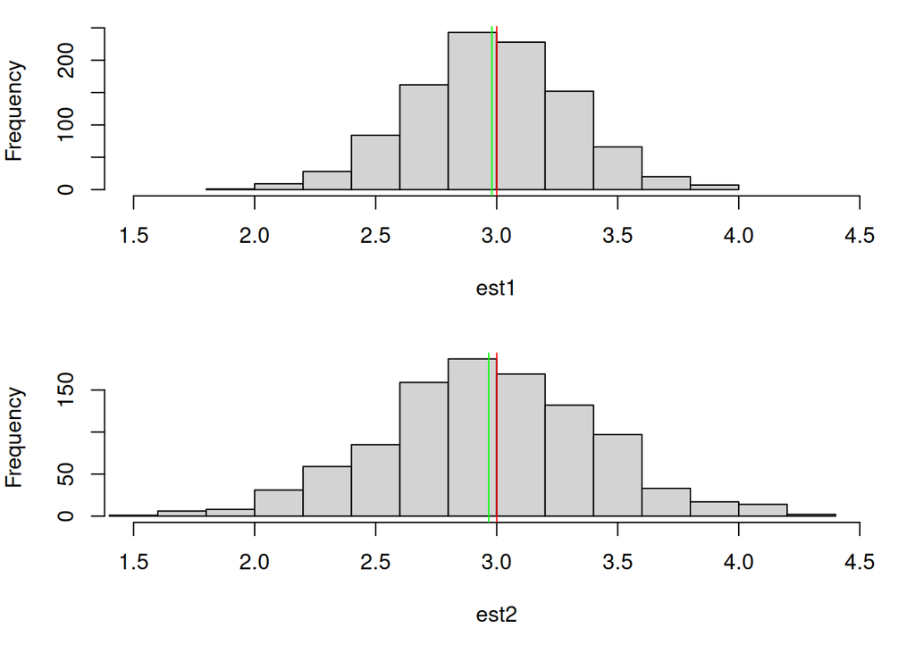

```r
par(mfrow=c(2,1),mar=c(5,4,1,1))
hist(est1,xlim=c(1.5,4.5),main="");
abline(v=mu,col="red"); abline(v=moyest1,col="green")
hist(est2,xlim=c(1.5,4.5),main="");
abline(v=mu,col="red"); abline(v=moyest2,col="green")
```

On confirme visuellement la réponse à la question précédente: les 2 estimateurs sont sans biais (verticale rouge=vert), mais T2 est plus étalé que T1.

```r
n <- 50
dataG50 <- matrix(rnorm(N*n,mu,sigma),nrow=N,ncol=n)
est150 <- rowSums(dataG50)/n
est250 <- (apply(dataG50,1,min)+apply(dataG50,1,max))/2
kable(data.frame(row.names=c("moy","sd"),est1=c(mean(est150), sd(est150)),est2=c(mean(est250), sd(est250))))
```

|  | est1 | est2 |
| --- | --- | --- |
| moy | 3.0033548 | 3.0186897 |
| sd | 0.1399515 | 0.3372698 |

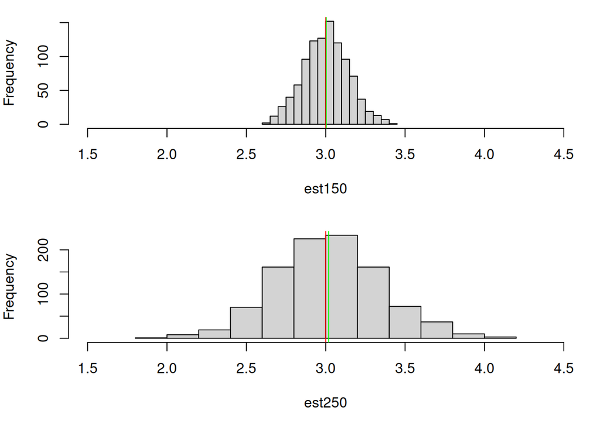

```r
par(mfrow=c(2,1),mar=c(5,4,1,1))
hist(est150,xlim=c(1.5,4.5),main=""); abline(v=mu,col="red"); abline(v=mean(est150),col="green")
hist(est250,xlim=c(1.5,4.5),main=""); abline(v=mu,col="red"); abline(v=mean(est250),col="green")
```

Oui, la différence est plus nette: l’écart type est 2 fois plus grand pour T2 que pour T1.

## Exercice 2

```r
mu <- 3; sigma <- 1; N <- 1000; n <- 10
dataG <- matrix(rnorm(N*n,mu,sigma),nrow=N,ncol=n)
```

```r
est2 <- apply(dataG, 1, var) # N réalisations de T2=S'^2
est1 <- est2*(n-1)/n # N réalisations de T1=S^2
```

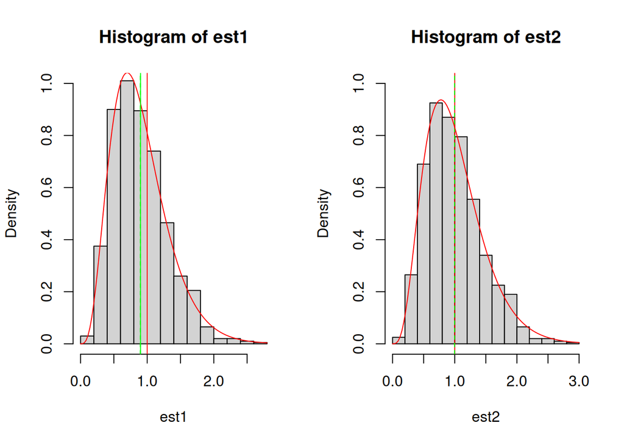

```r
par(mfrow=c(1,2))
hist(est1,prob=T,ylim=c(0,1)); abline(v=sigma^2,col="red");
abline(v=mean(est1),lty=2, col="green")
curve(n/sigma^2*dchisq(x*n/sigma^2,df=n-1),col="red",add=T)
abline(v=sigma^2*(n-1)/n,col="green")
hist(est2,prob=T,ylim=c(0,1)); abline(v=sigma^2,col="red");
abline(v=mean(est2),lty=2, col="green")
curve((n-1)/sigma^2*dchisq(x*(n-1)/sigma^2,df=n-1),col="red",add=T)
```

$\frac{n T_1}{\sigma^2}$ suit $\chi_{n-1}$. Si $f$ est la loi de densité du chi2, $f(t) dt = f(\frac{n}{\sigma^2} x) \frac{n}{\sigma^2} dx$. On observe bien que T1 est biaisé et non T2.

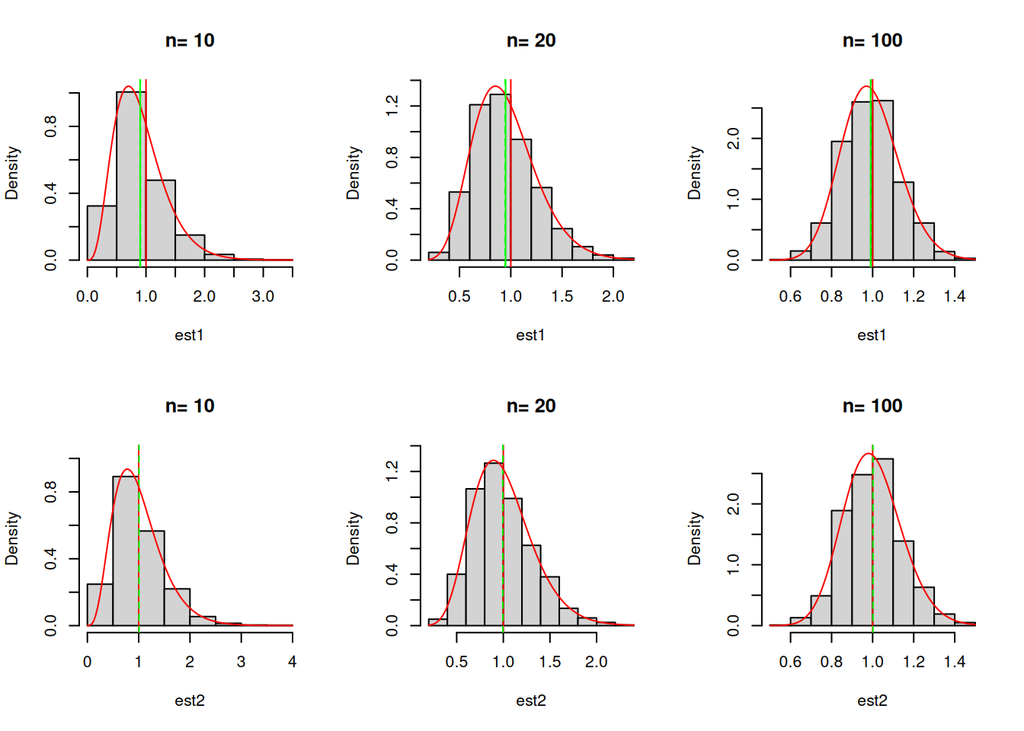

```r
par(mfcol=c(2,3))
for (n in c(10,20,100)) {
 maxp <- n/sigma^2*dchisq(which(dchisq(1:(2*n),n-1)==max(dchisq(1:(2*n),n-1))),n-1)
  dataG <- matrix(rnorm(N*n,mu,sigma),nrow=N,ncol=n)
 est1 <- apply(dataG, 1, var)*(n-1)/n
 est2 <- apply(dataG, 1, var)
 hist(est1,prob=T,ylim=c(0,maxp),main=paste("n=",n)); abline(v=sigma^2,col="red");
 abline(v=mean(est1),lty=2, col="green")
 curve(n/sigma^2*dchisq(x*n/sigma^2,df=n-1),col="red",add=T)
 abline(v=sigma^2*(n-1)/n,col="green")
 hist(est2,prob=T,ylim=c(0,maxp),main=paste("n=",n)); abline(v=sigma^2,col="red");
 abline(v=mean(est2),lty=2,  col="green")
 curve((n-1)/sigma^2*dchisq(x*(n-1)/sigma^2,df=n-1),col="red",add=T)
}
```

Si n est grand, le biais de $T_1$ disparait (on dit que $T_1$ est asymptotiquement sans biais) et $T_1$ et $T_2$ ont une loi qui ressemble beaucoup à une loi normale.

# Exercice 3

```r
p <- 0.5; N <- 1000; n <- 4
dataB <- matrix(rbinom(n*N,1,p),nrow=N,ncol=n)
```

```r
est <- rowSums(dataB)/n
```

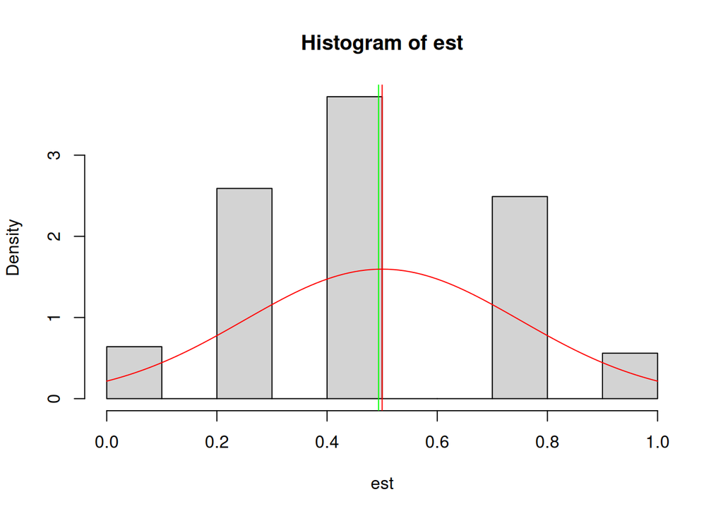

```r
hist(est,prob=TRUE)
abline(v=p,col="red")
abline(v=mean(est),col="green")
curve(dnorm(x,p,sqrt(p*(1-p)/n)),add=TRUE, col="red")
```

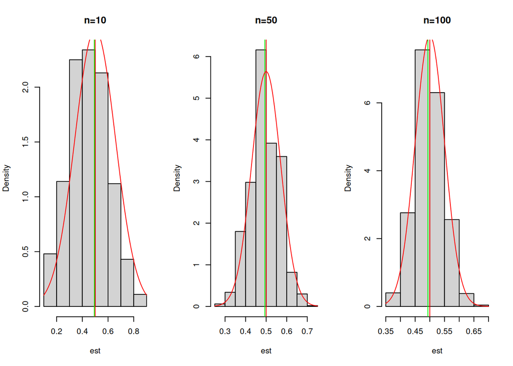

```r
par(mfrow=c(1,3))
for (n in c(10,50,100)) {
 hist(rowSums(matrix(rbinom(n*N,1,p),nrow=N,ncol=n))/n,prob=TRUE,main=paste0("n=",n),xlab="est")
 abline(v=p,col="red")
 abline(v=mean(est),col="green")
 curve(dnorm(x,p,sqrt(p*(1-p)/n)),add=TRUE, col="red")
}
```

$n>50$ pour avoir une loi normale pour l’estimateur. Oui, l’estimateur est sans biais quelque soit n.

# Exercice 4 (facultatif)

```r
a <- 2; N <- 1000; n <- 10
dataU <- matrix(runif(N*n,0,a),nrow=N,ncol=n)
est1 <- 2*apply(dataU,1,mean)
est2 <- apply(dataU,1,max)
cat("ecart type de est1:",sd(est1), "de est2:",sd(est2),"\n")
```

```
## ecart type de est1: 0.3614186 de est2: 0.1656859
```

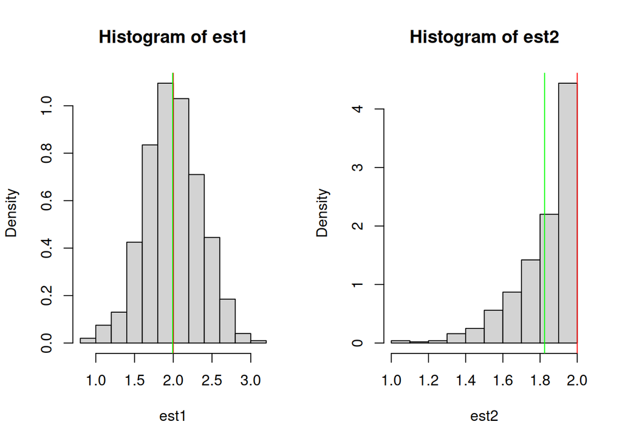

```r
par(mfrow=c(1,2))
hist(est1,prob=T); abline(v=a,col="red"); abline(v=mean(est1),col="green")
hist(est2,prob=T); abline(v=a,col="red"); abline(v=mean(est2),col="green")
```

Le second estimateur est plus précis mais il est biaisé et sa distribution n’est pas gaussienne mais elle peut se calculer explicitement (cf. TD).